# Lesson_4_screencast

### Brier Score

```python
random_predictions = np.random.random((100))
random_predictions
```

```
array([0.120537  , 0.67502419, 0.67441169, 0.29023812, 0.83552909,
       0.01647058, 0.75787316, 0.75360308, 0.34706988, 0.71055235,
       0.4832393 , 0.99055251, 0.39819498, 0.38348488, 0.30692003,
       0.32981952, 0.09541228, 0.73515065, 0.45322124, 0.97807213,
       0.83500484, 0.77919954, 0.29418619, 0.8798694 , 0.73418059,
       0.15172624, 0.09789331, 0.40738777, 0.41941159, 0.06539334,
       0.73811619, 0.5151421 , 0.13331427, 0.57099816, 0.47962095,
       0.88576205, 0.85406748, 0.50038306, 0.46389309, 0.71128672,
       0.22652938, 0.05299984, 0.9598917 , 0.76702888, 0.24531537,
       0.01949739, 0.06181394, 0.56165583, 0.87771174, 0.71694006,
       0.99064259, 0.01747636, 0.1255442 , 0.63966359, 0.62332809,
       0.11493323, 0.08578684, 0.89113703, 0.06653157, 0.26899445,
       0.00990481, 0.29594178, 0.96875865, 0.85079327, 0.15206869,
       0.20193147, 0.21760967, 0.58090312, 0.12240851, 0.28436165,
       0.13107635, 0.30609318, 0.86677683, 0.83838072, 0.55234128,
       0.12973619, 0.67196031, 0.04832953, 0.08698971, 0.83846205,
       0.72803319, 0.02707507, 0.23734983, 0.65254913, 0.69489243,
       0.34701425, 0.23677209, 0.76958291, 0.24822727, 0.57632746,
       0.6362575 , 0.93658516, 0.69984159, 0.06211591, 0.83859919,
       0.86480237, 0.45035829, 0.48692292, 0.6801571 , 0.67225319])
```

```python
random_labels = np.random.choice([0, 1], 100)
random_labels
```

```
array([1, 1, 1, 0, 0, 0, 1, 0, 1, 1, 0, 1, 0, 0, 0, 1, 1, 0, 0, 0, 1, 1,
       1, 0, 1, 1, 1, 0, 0, 1, 0, 0, 0, 0, 1, 1, 1, 0, 1, 0, 0, 1, 0, 1,
       0, 0, 0, 0, 1, 1, 0, 1, 1, 1, 0, 0, 0, 0, 1, 0, 1, 0, 1, 0, 1, 0,
       1, 0, 0, 1, 0, 1, 1, 0, 1, 1, 1, 0, 0, 0, 0, 1, 1, 1, 1, 1, 0, 1,
       1, 1, 0, 0, 1, 1, 1, 0, 0, 0, 1, 0])
```

- Convert probability to binary predictions

```python
probability_prediction_df = pd.DataFrame({"prob_prediction": random_predictions,
                "binary_prediction": np.array([ 1 if abs(x)>=0.5 else 0 for x in random_predictions], dtype=int),
                                "label": random_labels})
```

```python
probability_prediction_df.head()
```

|  | prob_prediction | binary_prediction | label |
| --- | --- | --- | --- |
| 0 | 0.120537 | 0 | 1 |
| 1 | 0.675024 | 1 | 1 |
| 2 | 0.674412 | 1 | 1 |
| 3 | 0.290238 | 0 | 0 |
| 4 | 0.835529 | 1 | 0 |

```python
y_true = probability_prediction_df['label'].values
y_pred = probability_prediction_df['binary_prediction'].values
```

```python
acc = accuracy_score(y_true, y_pred)
print(acc)
```

```
0.51
```

```python
bs_loss = brier_score_loss(y_true, probability_prediction_df['prob_prediction'])
print(bs_loss)
```

```
0.351639809400303
```

### Misclassified

```python
missclassified_df = probability_prediction_df[probability_prediction_df['binary_prediction']!=probability_prediction_df['label']]
```

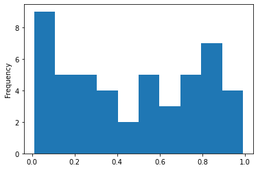

```python
missclassified_df['prob_prediction'].plot(kind='hist')
```

## 3. Demographic Group Bias Analysis

- Select groups to analyze
- Prepare data
- Analyze groups

### Select groups to analyze

- Selected 'origin' field which gives the country of origin for the car.

```python
#combine binary df with original test df, order was not shuffled so can do
```

```python
merged_binary_df = binary_df.assign(origin = test_data['Origin'].values)
```

```python
merged_binary_df.head()
```

|  | pred | actual_value | score | label_value | origin |
| --- | --- | --- | --- | --- | --- |
| 0 | 25.416197 | 15.0 | 1 | 0 | USA |
| 1 | 26.598448 | 10.0 | 1 | 0 | USA |
| 2 | 25.643915 | 9.0 | 1 | 0 | USA |
| 3 | 24.626881 | 25.0 | 0 | 1 | Japan |
| 4 | 20.323015 | 19.0 | 0 | 0 | USA |

### Prepare Data

```python
# Aequitas
from aequitas.preprocessing import preprocess_input_df
from aequitas.group import Group
from aequitas.plotting import Plot
from aequitas.bias import Bias
from aequitas.fairness import Fairness
```

```python
ae_df, _ = preprocess_input_df(merged_binary_df)
g = Group()
xtab, _ = g.get_crosstabs(ae_df)
absolute_metrics = g.list_absolute_metrics(xtab)
clean_xtab = xtab.fillna(-1)
aqp = Plot()
b = Bias()
```

```
model_id, score_thresholds 1 {'rank_abs': [39]}
```

### Analyze Groups

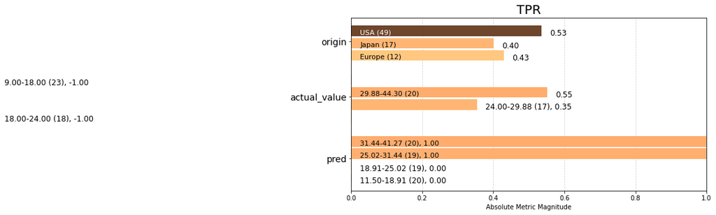

```python
tpr = aqp.plot_group_metric(clean_xtab, 'tpr', min_group_size=0.05)
```

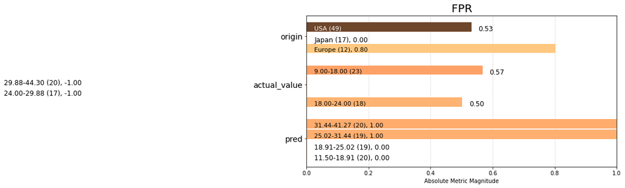

```python
fpr = aqp.plot_group_metric(clean_xtab, 'fpr', min_group_size=0.05)
```

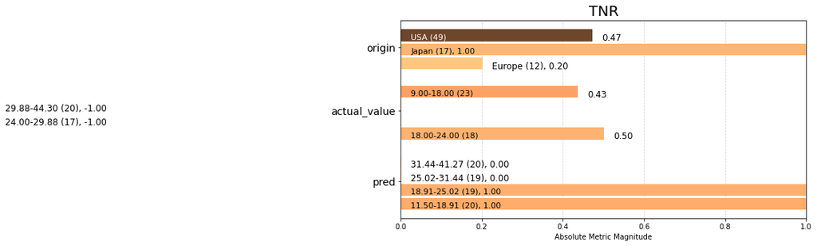

```python
tnr = aqp.plot_group_metric(clean_xtab, 'tnr', min_group_size=0.05)
```

```python
# Bias Report - http://aequitas.dssg.io/audit/eg1cp7ku/adult_rf_binary/
```

## 4. Train Uncertainty Estimation Model with TF Probability

### Instructions

- Using MPG model from earlier, create uncertainty estimation model with TF Probability.
- In particular, we will focus on building a model that accounts for Aleatoric Uncertainty.

```python
import tensorflow_probability as tfp
```

### Aleatoric Uncertainty

- Known Unknowns
- 2 Main Changes to our network
  - Add a second unit to the last dense layer before passing it to Tensorflow Probability layer to model for the predictor y and the heteroscedasticity or unequal scattering of data
  - DistributionLambda distribution mean and std
- DistributionLambda is a special Keras layer that uses a Python lambda to construct a distribution based on the layer inputs and the output of the final layer of the model is passed into the loss function. Lastly. this model will return a distribution for both mean and standard deviation.

```python
train_label_stats = train_labels.describe()
train_label_stats
```

```
count    314.000000
mean      23.310510
std        7.728652
min       10.000000
25%       17.000000
50%       22.000000
75%       28.950000
max       46.600000
Name: MPG, dtype: float64
```

```python
def build_seq_prob_model(feature_layer):
    model = tf.keras.Sequential([
        feature_layer,
        tf.keras.layers.Dense(150, activation='relu'),
        tf.keras.layers.Dense(75, activation='relu'),
        tf.keras.layers.Dense(1 + 1),
        tfp.layers.DistributionLambda(
            lambda t:tfp.distributions.Normal(
                loc=t[..., :1],
                scale=1e-3 + tf.math.softplus(0.1 * t[...,1:])

            )
         )



    ])
    return model

def build_prob_model(train_ds,   feature_layer,  epochs=5, loss_metric='mse'):
    model = build_seq_prob_model(feature_layer)
    negloglik = lambda y, rv_y: -rv_y.log_prob(y)
    loss = negloglik
    model.compile(tf.optimizers.Adam(learning_rate=0.05), loss=loss, metrics=[loss_metric])
    history = model.fit(train_ds,
                        epochs=epochs)
    return model, history
```

### Train Probability Model

```python
prob_model, history = build_prob_model(train_ds, dense_feature_layer,  epochs=500)
```

```
Train for 3 steps
```